# Integrated CA1 - 2º Semester

Programme Title: HDIP in Science in Data Analytics for Business

Student Name: Renata Oliveira Souza

ID Number: 2025064

CCT College Dublin – February 2025

Modules: HDIP Machine Learning — CA1

Professor: Dr. Muhammad Iqbal

Submission Date: 02 Novembro 2025

# Introduction and Objectives

This project analyzes the King County housing market using machine learning to study the key drivers and trends impacting the price of houses. The study utilizes clustering KMeans and Agglomerative in addition to time forecasting using ARIMA to profile similar houses and predict the price changes over time.

# Motivation

The motivation stems from the necessity of acquiring actionable insights in real estate. The complexity of the location, size and quality relationship, and other key determinants of value is pronounced, and machine learning can increases the value of prediction and strategic decision making.

```python
# 1:imports and configuration
import pandas as pd
import numpy as np
import matplotlib.pyplot as plt

from sklearn.preprocessing import StandardScaler
from sklearn.decomposition import PCA
from sklearn.cluster import KMeans, AgglomerativeClustering
from sklearn.metrics import silhouette_score, davies_bouldin_score

import warnings
warnings.filterwarnings("ignore")

pd.set_option("display.max_columns", None)
```

# Problem Statement

The core question is to what extent clustering and forecasting can aid in making informed business and policy decisions in the housing market by grouping properties and projecting price trends.

```python
import pandas as pd

path = "kc_house_data.csv"

try:
    df = pd.read_csv(path)
except pd.errors.ParserError:
    # Modo tolerante: engine python, ignora linhas ruins e lida com BOM/escape
    df = pd.read_csv(
        path,
        engine="python",
        sep=",",
        quotechar='"',
        escapechar="\\",
        encoding="utf-8-sig",
        on_bad_lines="skip"   # ou "warn" para avisar sem pular
    )

print(df.shape)
df.head(3)
```

```
(9007, 21)
```

|  | id | date | price | bedrooms | bathrooms | sqft_living | sqft_lot | floors | waterfront | view | condition | grade | sqft_above | sqft_basement | yr_built | yr_renovated | zipcode | lat | long | sqft_living15 | sqft_lot15 |
| --- | --- | --- | --- | --- | --- | --- | --- | --- | --- | --- | --- | --- | --- | --- | --- | --- | --- | --- | --- | --- | --- |
| 0 | 7129300520 | 20141013T000000 | 221900.0 | 3 | 1.00 | 1180 | 5650 | 1.0 | 0 | 0 | 3 | 7 | 1180 | 0 | 1955 | 0 | 98178 | 47.5112 | -122.257 | 1340 | 5650 |
| 1 | 6414100192 | 20141209T000000 | 538000.0 | 3 | 2.25 | 2570 | 7242 | 2.0 | 0 | 0 | 3 | 7 | 2170 | 400 | 1951 | 1991 | 98125 | 47.7210 | -122.319 | 1690 | 7639 |
| 2 | 5631500400 | 20150225T000000 | 180000.0 | 2 | 1.00 | 770 | 10000 | 1.0 | 0 | 0 | 3 | 6 | 770 | 0 | 1933 | 0 | 98028 | 47.7379 | -122.233 | 2720 | 8062 |

# Dataset Description

The dataset comprises 2014-15 house sales in King County (Seattle) and consists of price, location, structure, and date variables. The dataset enables both clustering and time series forecasting.

```python
# Overview
df.info()
df.describe().T
```

```
<class 'pandas.core.frame.DataFrame'>
RangeIndex: 9007 entries, 0 to 9006
Data columns (total 21 columns):
 #   Column         Non-Null Count  Dtype
---  ------         --------------  -----
 0   id             9007 non-null   int64
 1   date           9007 non-null   object
 2   price          9007 non-null   float64
 3   bedrooms       9007 non-null   int64
 4   bathrooms      9007 non-null   float64
 5   sqft_living    9007 non-null   int64
 6   sqft_lot       9007 non-null   int64
 7   floors         9007 non-null   float64
 8   waterfront     9007 non-null   int64
 9   view           9007 non-null   int64
 10  condition      9007 non-null   int64
 11  grade          9007 non-null   int64
 12  sqft_above     9007 non-null   int64
 13  sqft_basement  9007 non-null   int64
 14  yr_built       9007 non-null   int64
 15  yr_renovated   9007 non-null   int64
 16  zipcode        9007 non-null   int64
 17  lat            9007 non-null   float64
 18  long           9007 non-null   float64
 19  sqft_living15  9007 non-null   int64
 20  sqft_lot15     9007 non-null   int64
dtypes: float64(5), int64(15), object(1)
memory usage: 1.4+ MB
```

|  | count | mean | std | min | 25% | 50% | 75% | max |
| --- | --- | --- | --- | --- | --- | --- | --- | --- |
| id | 9007.0 | 4.574579e+09 | 2.866582e+09 | 1.000102e+06 | 2.124875e+09 | 3.905082e+09 | 7.284900e+09 | 9.842301e+09 |
| price | 9007.0 | 5.337454e+05 | 3.782029e+05 | 7.500000e+04 | 3.150000e+05 | 4.450000e+05 | 6.390000e+05 | 7.700000e+06 |
| bedrooms | 9007.0 | 3.359609e+00 | 9.085564e-01 | 0.000000e+00 | 3.000000e+00 | 3.000000e+00 | 4.000000e+00 | 1.100000e+01 |
| bathrooms | 9007.0 | 2.061924e+00 | 7.640369e-01 | 0.000000e+00 | 1.500000e+00 | 2.000000e+00 | 2.500000e+00 | 8.000000e+00 |
| sqft_living | 9007.0 | 2.050415e+03 | 9.098113e+02 | 3.800000e+02 | 1.410000e+03 | 1.890000e+03 | 2.500000e+03 | 1.205000e+04 |
| sqft_lot | 9007.0 | 1.599870e+04 | 4.535409e+04 | 5.720000e+02 | 5.424000e+03 | 7.902000e+03 | 1.110800e+04 | 1.651359e+06 |
| floors | 9007.0 | 1.430998e+00 | 5.105336e-01 | 1.000000e+00 | 1.000000e+00 | 1.000000e+00 | 2.000000e+00 | 3.500000e+00 |
| waterfront | 9007.0 | 8.104807e-03 | 8.966611e-02 | 0.000000e+00 | 0.000000e+00 | 0.000000e+00 | 0.000000e+00 | 1.000000e+00 |
| view | 9007.0 | 2.402576e-01 | 7.700307e-01 | 0.000000e+00 | 0.000000e+00 | 0.000000e+00 | 0.000000e+00 | 4.000000e+00 |
| condition | 9007.0 | 3.445764e+00 | 6.652152e-01 | 1.000000e+00 | 3.000000e+00 | 3.000000e+00 | 4.000000e+00 | 5.000000e+00 |
| grade | 9007.0 | 7.594093e+00 | 1.173018e+00 | 3.000000e+00 | 7.000000e+00 | 7.000000e+00 | 8.000000e+00 | 1.300000e+01 |
| sqft_above | 9007.0 | 1.747185e+03 | 8.078675e+02 | 3.800000e+02 | 1.180000e+03 | 1.530000e+03 | 2.130000e+03 | 8.570000e+03 |
| sqft_basement | 9007.0 | 3.032303e+02 | 4.518144e+02 | 0.000000e+00 | 0.000000e+00 | 0.000000e+00 | 6.000000e+02 | 4.820000e+03 |
| yr_built | 9007.0 | 1.967277e+03 | 2.803047e+01 | 1.900000e+03 | 1.950000e+03 | 1.969000e+03 | 1.990000e+03 | 2.015000e+03 |
| yr_renovated | 9007.0 | 8.976996e+01 | 4.137535e+02 | 0.000000e+00 | 0.000000e+00 | 0.000000e+00 | 0.000000e+00 | 2.015000e+03 |
| zipcode | 9007.0 | 9.807808e+04 | 5.392851e+01 | 9.800100e+04 | 9.803300e+04 | 9.806500e+04 | 9.811800e+04 | 9.819900e+04 |
| lat | 9007.0 | 4.756051e+01 | 1.398720e-01 | 4.715590e+01 | 4.746455e+01 | 4.757360e+01 | 4.767950e+01 | 4.777760e+01 |
| long | 9007.0 | -1.222143e+02 | 1.393850e-01 | -1.225140e+02 | -1.223250e+02 | -1.222310e+02 | -1.221270e+02 | -1.213150e+02 |
| sqft_living15 | 9007.0 | 1.972923e+03 | 6.719593e+02 | 6.200000e+02 | 1.490000e+03 | 1.830000e+03 | 2.340000e+03 | 5.790000e+03 |
| sqft_lot15 | 9007.0 | 1.322487e+04 | 2.600274e+04 | 6.600000e+02 | 5.413000e+03 | 7.847000e+03 | 1.036950e+04 | 4.382130e+05 |

```python
# Check for nulls
df.isna().sum().sort_values(ascending=False).head(10)
```

```
id               0
grade            0
sqft_living15    0
long             0
lat              0
zipcode          0
yr_renovated     0
yr_built         0
sqft_basement    0
sqft_above       0
dtype: int64
```

# Data Preparation and Feature Engineering

Data was cleaned to remove missing or unrealistic values. Two derived attributes were added: house_age (age at sale) and price_per_sqft (value per square foot). Outliers were trimmed to improve clustering stability.

```python
df['date'] = pd.to_datetime(df['date'], errors='coerce')

# Useful derived attributes
df['year'] = df['date'].dt.year
df['month'] = df['date'].dt.month

# Approximate age at the time of sale
df['house_age'] = df['year'] - df['yr_built']

# Price per square foot
df['price_per_sqft'] = df['price'] / df['sqft_living']

# Remove records with unrealistic or critical null values
cols_core = ['price','sqft_living','lat','long','zipcode','year','month','house_age','price_per_sqft']
df_clean = df.dropna(subset=cols_core).copy()

# Trim extreme outliers of price_per_sqft (1%–99%) for more stable clustering
low, high = df_clean['price_per_sqft'].quantile([0.01, 0.99])
df_clean = df_clean[(df_clean['price_per_sqft']>=low) & (df_clean['price_per_sqft']<=high)]

df_clean.shape
```

```
(8825, 25)
```

# Standardization

All numerical features were scaled using z-score normalization to ensure comparability and balanced contribution in distance-based clustering.

```python
# Selection of numerical features for segmentation
features = [
    'price', 'bedrooms', 'bathrooms', 'sqft_living', 'sqft_lot',
    'floors', 'waterfront', 'view', 'condition', 'grade',
    'sqft_above', 'sqft_basement', 'lat', 'long',
    'house_age', 'price_per_sqft'
]

X = df_clean[features].copy()

# Fill any remaining nulls (rare) with the median
X = X.fillna(X.median(numeric_only=True))

# Scale the data
scaler = StandardScaler()
X_scaled = scaler.fit_transform(X)
```

# Clustering

```python
# Evaluate KMeans for K=2..10
results = []
for k in range(2, 11):
    km = KMeans(n_clusters=k, n_init=10, random_state=42)
    labels = km.fit_predict(X_scaled)
    sil = silhouette_score(X_scaled, labels)
    dbi = davies_bouldin_score(X_scaled, labels)
    results.append((k, sil, dbi))

res_df = pd.DataFrame(results, columns=['k','silhouette','davies_bouldin']).sort_values('k')
res_df
```

|  | k | silhouette | davies_bouldin |
| --- | --- | --- | --- |
| 0 | 2 | 0.226137 | 1.800476 |
| 1 | 3 | 0.200443 | 1.808250 |
| 2 | 4 | 0.146445 | 1.649061 |
| 3 | 5 | 0.177902 | 1.607803 |
| 4 | 6 | 0.165731 | 1.541571 |
| 5 | 7 | 0.170780 | 1.465959 |
| 6 | 8 | 0.162020 | 1.484488 |
| 7 | 9 | 0.154655 | 1.536550 |
| 8 | 10 | 0.164355 | 1.464253 |

# Cluster Interpretation

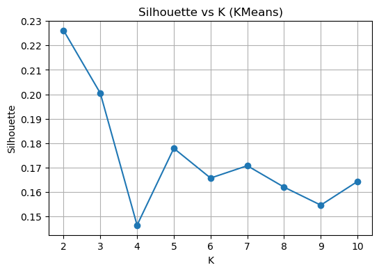

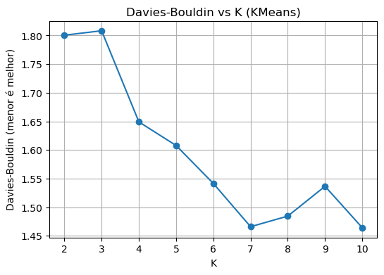

```python
# Quick plot
plt.figure(figsize=(6,4))
plt.plot(res_df['k'], res_df['silhouette'], marker='o')
plt.title('Silhouette vs K (KMeans)')
plt.xlabel('K'); plt.ylabel('Silhouette'); plt.grid(True)
plt.show()

plt.figure(figsize=(6,4))
plt.plot(res_df['k'], res_df['davies_bouldin'], marker='o')
plt.title('Davies-Bouldin vs K (KMeans)')
plt.xlabel('K'); plt.ylabel('Davies-Bouldin (menor é melhor)'); plt.grid(True)
plt.show()
```

```python
# Choose the optimal K using a simple rule: highest silhouette and, in case of a tie, lowest DBI
best = res_df.sort_values(['silhouette','davies_bouldin'], ascending=[False,True]).iloc[0]
best_k = int(best['k']); best
```

```
k                 2.000000
silhouette        0.226137
davies_bouldin    1.800476
Name: 0, dtype: float64
```

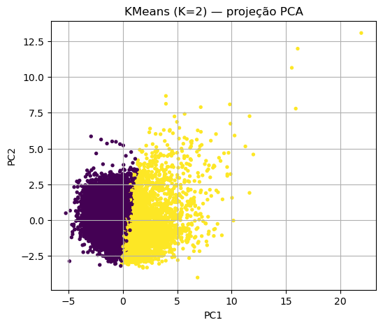

```
{'KMeans': {'silhouette': 0.22613670203988306, 'DBI': 1.8004763842238565}, 'Agglomerative': {'silhouette': 0.1927888893376045, 'DBI': 2.030652267755278}}
```

```python
# Fit final KMeans and apply PCA for 2D visualization
kmeans = KMeans(n_clusters=best_k, n_init=20, random_state=42)
labels_km = kmeans.fit_predict(X_scaled)

pca = PCA(n_components=2, random_state=42)
pts2d = pca.fit_transform(X_scaled)

plt.figure(figsize=(6,5))
plt.scatter(pts2d[:,0], pts2d[:,1], c=labels_km, s=8)
plt.title(f'KMeans (K={best_k}) — projeção PCA')
plt.xlabel('PC1'); plt.ylabel('PC2'); plt.grid(True)
plt.show()

# Compare with Agglomerative clustering
agg = AgglomerativeClustering(n_clusters=best_k, linkage='ward')
labels_agg = agg.fit_predict(X_scaled)

sil_km = silhouette_score(X_scaled, labels_km)
dbi_km = davies_bouldin_score(X_scaled, labels_km)
sil_agg = silhouette_score(X_scaled, labels_agg)
dbi_agg = davies_bouldin_score(X_scaled, labels_agg)

print({'KMeans': {'silhouette': sil_km, 'DBI': dbi_km},
       'Agglomerative': {'silhouette': sil_agg, 'DBI': dbi_agg}})
```